# Comparing velocity packages

Brunno Oliveira

13 December, 2023

# 1 setup

```r
# devtools::install_github("cbrown5/vocc")
# devtools::install_github("oliveirab/VoCC", build_vignettes = FALSE)

list.of.packages <- c("climetrics","vocc","VoCC1","terra","ggplot2","GGally","data.table","geodata","tidyterra","gridExtra","microbenchmark")
new.packages <- list.of.packages[!(list.of.packages %in% installed.packages()[,"Package"])]
if(length(new.packages)) install.packages(new.packages)
sapply(list.of.packages, require, character.only = TRUE)
```

```
##     climetrics           vocc          VoCC1          terra        ggplot2
##           TRUE           TRUE           TRUE           TRUE           TRUE
##         GGally     data.table        geodata      tidyterra      gridExtra
##           TRUE           TRUE           TRUE           TRUE           TRUE
## microbenchmark
##           TRUE
```

```r
# Source velocity functions adapted from the package climetrics after applying some corrections described below
# source("/storage/simple/projects/t_cesab/brunno/Exposure-SDM/R/velocity_functions.R")
source(here::here("R/velocity_functions.R"))
# Source function generated by biov1 to create the spatial gradient at the latitudinal direction.
source(here::here("R/gael_velocity.R"))
# Source settings (here used only to the Eckert equal area projection)
source(here::here("R/settings.R"))

bearing_to_angle <- function(x) ifelse(x <=90, (90-x), (360 - (x - 90)))
```

# 2 Compare velocity R-packages

In order to generate comparable results across multiple R packages, we sourced climate data from the package `climetrics.` These represent monthly mean annual temperature from Jan 1991 to Dec 2020. The geographical area covers North of France, Great Britain and West of Norway.

## 2.1 Get temperature data

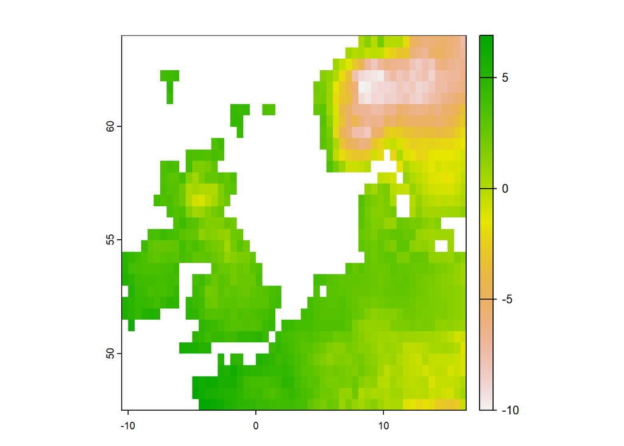

```r
# path to the dataset folder
filePath <- system.file("external/", package="climetrics")
tmean1 <- rast(paste0(filePath,'/tmean.tif'))
plot(tmean1[[1]])
```

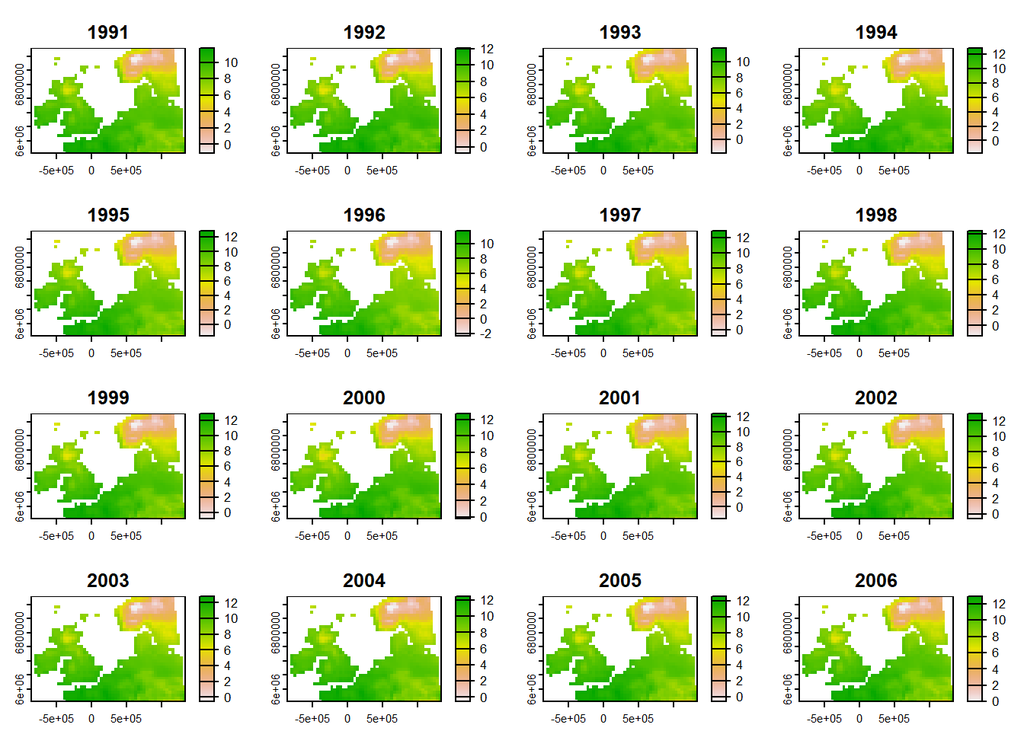

```r
# corresponding dates
n <- readRDS(paste0(filePath,'/dates.rds'))

# get averages per year
terra::time(tmean1) <- as.Date(n)
tmean1 <- tapp(tmean1, "years", mean)

# project to equal area
tmean <- terra::project(tmean1,Eckt)
plot(tmean)
```

```r
# Global continental lines
globe_lines <- vect(rnaturalearth::ne_countries(scale = "small"))
globe_lines <- terra::aggregate(globe_lines)
```

## 2.2 Calculate velocities

### 2.2.1 `Climetrics`

This package is based on the package vocc (not VoCC!). I found that both packages have an issue when calculating the spatial gradient. The issue is that when extracting environmental data from the RasterStack they use only the first year to calculate the spatial gradient. Instead, the package VoCC uses the mean of all years (calc(r,mean)), which is the correct thing to do! To prove this issue, I calculate velocity with this package using the both the default (wrong) method and the corrected procedure (using mean raster).

```r
### Right way
# Trend
trend_climetrics <- climetrics:::.tempgradTerra(tmean)

# Spatial gradient
spgrad_climetrics2 <- climetrics:::.spatialgradTerra(mean(tmean))

spgrad_climetrics2$NS[is.na(spgrad_climetrics2$NS)] <- 0
spgrad_climetrics2$WE[is.na(spgrad_climetrics2$WE)] <- 0
spgrad_climetrics2$NAsort <- ifelse((abs(spgrad_climetrics2$NS)+abs(spgrad_climetrics2$WE)) == 0, NA, 1)
spgrad_climetrics2$Grad <- spgrad_climetrics2$NAsort * sqrt((spgrad_climetrics2$WE^2) + (spgrad_climetrics2$NS^2))

# Velocity
v_climetrics2 <- climetrics:::.calcvelocity(grad = spgrad_climetrics2,
                                            slope = trend_climetrics,
                                            .terra = TRUE)

# benchmark
climetrics_time <- microbenchmark(
  {
    ### Right way
    # Trend
    trend_climetrics <- climetrics:::.tempgradTerra(tmean)
  },
  {
    # Spatial gradient
    spgrad_climetrics2 <- climetrics:::.spatialgradTerra(mean(tmean))

    spgrad_climetrics2$NS[is.na(spgrad_climetrics2$NS)] <- 0
    spgrad_climetrics2$WE[is.na(spgrad_climetrics2$WE)] <- 0
    spgrad_climetrics2$NAsort <- ifelse((abs(spgrad_climetrics2$NS)+abs(spgrad_climetrics2$WE)) == 0, NA, 1)
    spgrad_climetrics2$Grad <- spgrad_climetrics2$NAsort * sqrt((spgrad_climetrics2$WE^2) + (spgrad_climetrics2$NS^2))
  },
  {
    # Velocity
    v_climetrics2 <- climetrics:::.calcvelocity(grad = spgrad_climetrics2,
                                                slope = trend_climetrics,
                                                .terra = TRUE)
  },
  times = 10
)

### Wrong way
# Velocity
v_climetrics1 <- climetrics:::gVelocity(tmean)

# Spatial gradient (wrong way)
spgrad_climetrics1 <- climetrics:::.spatialgradTerra(tmean)

spgrad_climetrics1$NS[is.na(spgrad_climetrics1$NS)] <- 0
spgrad_climetrics1$WE[is.na(spgrad_climetrics1$WE)] <- 0
spgrad_climetrics1$NAsort <- ifelse((abs(spgrad_climetrics1$NS)+abs(spgrad_climetrics1$WE)) == 0, NA, 1)
spgrad_climetrics1$Grad <- spgrad_climetrics1$NAsort * sqrt((spgrad_climetrics1$WE^2) + (spgrad_climetrics1$NS^2))

# Angles
grad_ang_climetrics1 <- spgrad_climetrics1$angle


# Angles
grad_ang_climetrics2 <- spgrad_climetrics2$angle
```

### 2.2.2 `vocc`

Note that the same issue described above happens here. Thus, I calculate velocity with this package using the both the default (wrong) and the correct procedure (using mean raster).

```r
# Trend
trend_vocc = vocc::calcslope(rx = stack(tmean),
                             divisor = 1) # to get C/year

### Right way
# spatial gradient
spgrad_out_vocc2 = vocc::spatialgrad(rx = mean(stack(tmean)),
                                     y_dist = res(stack(tmean)),
                                     y_diff = NA)

# Calculating temperature velocity
v_vocc2 = vocc::calcvelocity(grad = spgrad_out_vocc2,
                             slope = trend_vocc)

v_vocc_rast2 <- rast(stack(tmean)[[1]])
v_vocc_rast2[] <- v_vocc2$velocity


# benchmark
vocc_time <- microbenchmark(
  {
    # Trend
    trend_vocc = vocc::calcslope(rx = stack(tmean),
                                 divisor = 1) # to get C/year
  },
  {
    ### Right way
    # spatial gradient
    spgrad_out_vocc2 = vocc::spatialgrad(rx = mean(stack(tmean)),
                                         y_dist = res(stack(tmean)),
                                         y_diff = NA)
  },
  {
    # Calculating temperature velocity
    v_vocc2 = vocc::calcvelocity(grad = spgrad_out_vocc2,
                                 slope = trend_vocc)

    v_vocc_rast2 <- rast(stack(tmean)[[1]])
    v_vocc_rast2[] <- v_vocc2$velocity
  },
  times = 10
)


### Wrong way
# Spatial gradient
spgrad_out_vocc1 = vocc::spatialgrad(rx = stack(tmean),
                                     y_dist = res(stack(tmean)),
                                     y_diff = NA)
# Calculating temperature velocity
v_vocc1 = vocc::calcvelocity(grad = spgrad_out_vocc1,
                             slope = trend_vocc)
v_vocc_rast1 <- rast(stack(tmean)[[1]])
v_vocc_rast1[] <- v_vocc1$velocity

# Angle
grad_ang_vocc1 = spgrad_out_vocc1$angle

# Angle
grad_ang_vocc2 = spgrad_out_vocc2$angle
```

### 2.2.3 `VoCC`

```r
# calculate the trend
trend_VoCC = VoCC1::tempTrend(r = stack(tmean),
                              th = 0.25*nlyr(tmean) ## set minimum # obs. to 1/4 time series length
)

# calculate the spatial gradient
spgrad_VoCC = VoCC1::spatGrad(r = stack(tmean),
                              projected = TRUE)

# Calculating temperature velocity
v_VoCC = VoCC1::gVoCC(tempTrend = trend_VoCC,
                      spatGrad = spgrad_VoCC)


# benchmark
VoCC_time <- microbenchmark(
  {
    # calculate the trend
    trend_VoCC = VoCC1::tempTrend(r = stack(tmean),
                                  th = 0.25*nlyr(tmean) ## set minimum # obs. to 1/4 time series length
    )
  },
  {
    # calculate the spatial gradient
    spgrad_VoCC = VoCC1::spatGrad(r = stack(tmean),
                                  projected = TRUE)
  },
  {
    # Calculating temperature velocity
    v_VoCC = VoCC1::gVoCC(tempTrend = trend_VoCC,
                          spatGrad = spgrad_VoCC)
  },
  times = 10
)

# Angle
grad_ang_VoCC = spgrad_VoCC$Ang[]
```

### 2.2.4 `bioshifts v3`

Functions adapted from climetrics (because it is based on the package `terra`, which allows faster computation relative to other packages that are based on `raster`), applying modifications to generate results in km/year.

```r
# Trend
trend_biov3 <- temp_grad(tmean, th = 0.25*nlyr(tmean))

# Spatial gradient
spgrad_biov3 <- spatial_grad(tmean)

# Velocity
v_biov3 <- gVelocity(spgrad_biov3,trend_biov3,truncate = FALSE)


# benchmark
biov3_time <- microbenchmark(
  {
    # Trend
    trend_biov3 <- temp_grad(tmean, th = 0.25*nlyr(tmean))
  },
  {
    # Spatial gradient
    spgrad_biov3 <- spatial_grad(tmean)
  },
  {
    # Velocity
    v_biov3 <- gVelocity(spgrad_biov3,trend_biov3,truncate = FALSE)
  },
  times = 10
)

v_biov3_angle <- v_biov3$Ang
v_biov3 <- v_biov3$Vel

# Angle
grad_ang_biov3 = spgrad_biov3$angle
```

### 2.2.5 `bioshifts v1`

```r
# spatial gradient
spgrad_biov1 <- Gael_grad(stack(tmean))
# trend (use VoCC trend function)
trend_biov1 <- VoCC1::tempTrend(r = stack(tmean), th = 10)
trend_biov1 = resample(trend_biov1, spgrad_biov1)

v_biov1 = trend_biov1[[1]] / spgrad_biov1
v_biov1 = resample(v_biov1, stack(tmean))

# Correcting velocities in North Hemisphere
lat <- raster::coordinates(v_biov1)[,2]
v_biov1[which(lat>0)] <- v_biov1[which(lat>0)]*-1
```

# 3 Compare results

## 3.1 Velocities maps

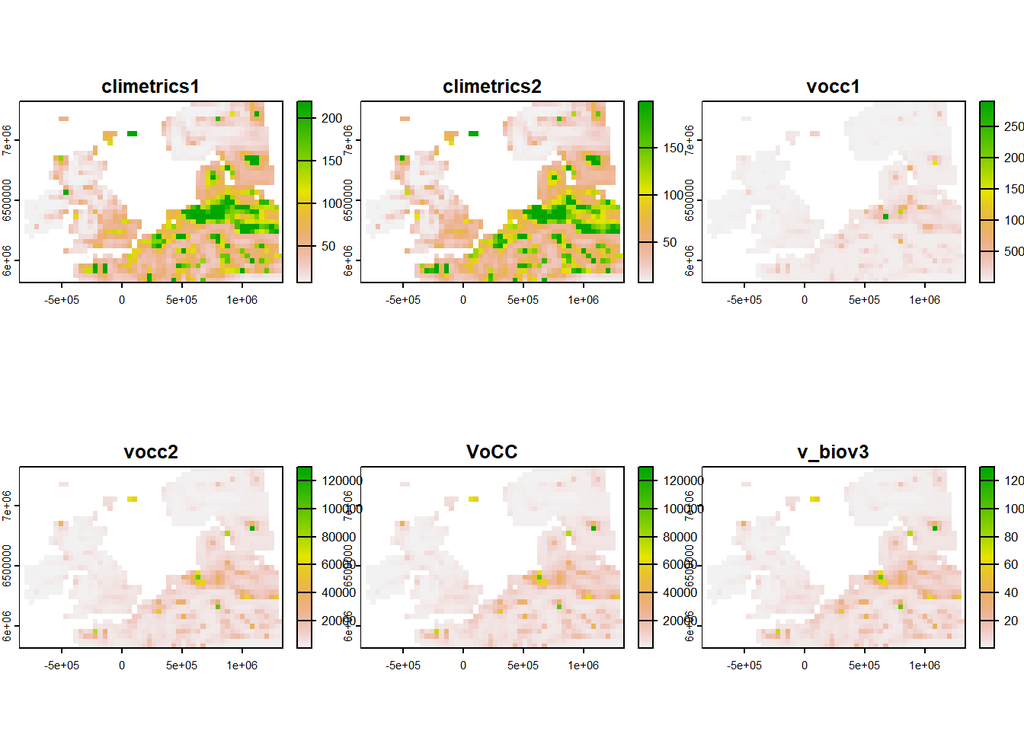

```r
tmp <- rast(c(climetrics1=v_climetrics1,
              climetrics2=v_climetrics2,
              vocc1=v_vocc_rast1,
              vocc2=v_vocc_rast2,
              VoCC=rast(v_VoCC[[1]]),
              v_biov3=v_biov3))

plot(tmp)
```

Quite different values.

## 3.2 Velocities correlations

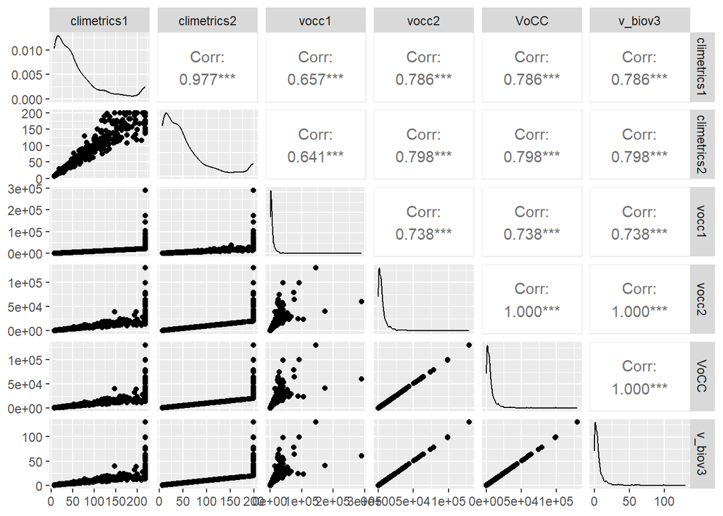

```r
velocities <- data.frame(tmp)

ggpairs(velocities)
```

## 3.3 Angle correlations

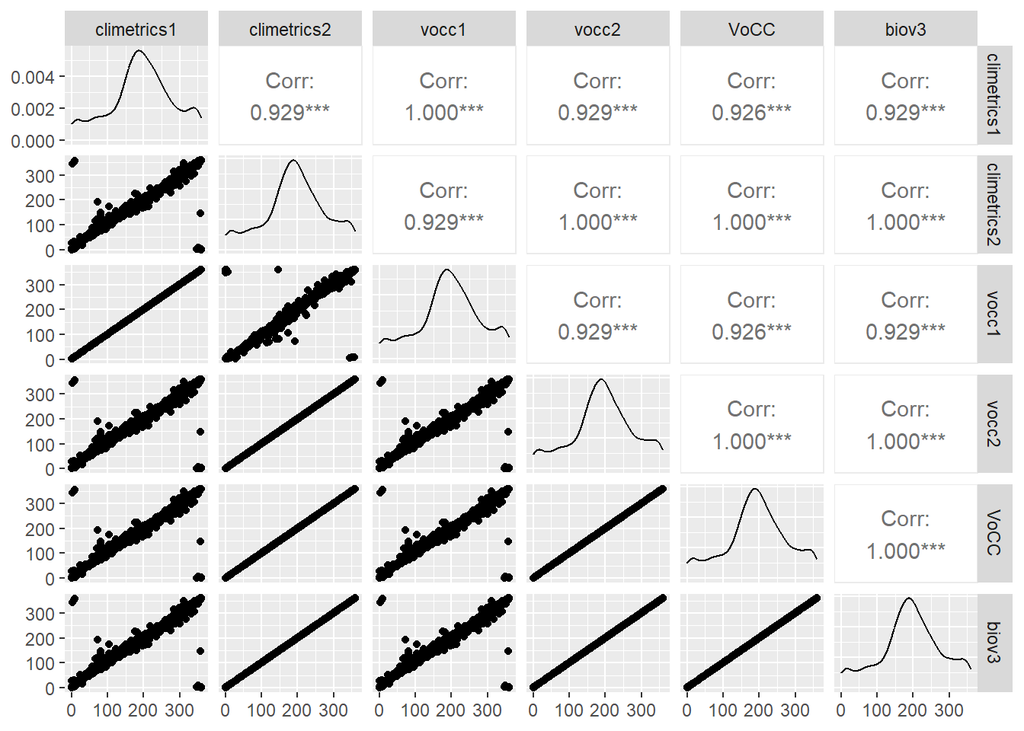

```r
# Gradient angles
angles <- data.frame(climetrics1=grad_ang_climetrics1,
                     climetrics2=grad_ang_climetrics2,
                     vocc1=grad_ang_vocc1,
                     vocc2=grad_ang_vocc2,
                     VoCC=grad_ang_VoCC,
                     biov3=grad_ang_biov3)

ggpairs(angles)
```

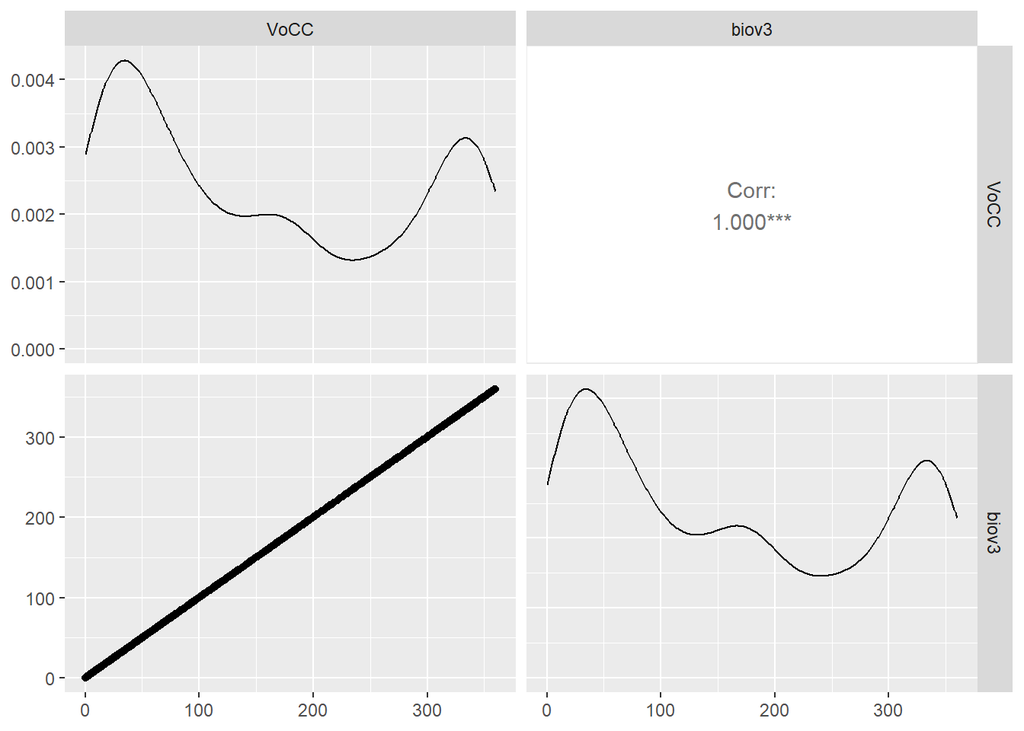

```r
# Velocity angles
angles <- data.frame(VoCC=rast(v_VoCC$voccAng)[][,1],
                     biov3=v_biov3_angle[][,1])

ggpairs(angles)
```

Gradient angles are very similar across packages and they all peak at around 200 degrees, meaning mainly South direction. This is the opposite of velocity trajectory, which always goes in the opposite direction of the environmental gradient when the trend is positive.

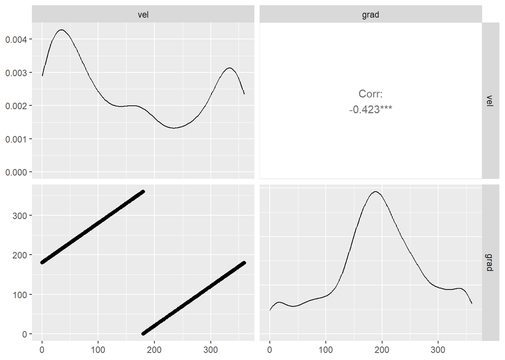

```r
# Velocity angle vs gradient angle
angles <- data.frame(vel=v_VoCC$voccAng[],
                     grad=grad_ang_VoCC)
ggpairs(angles)
```

This shows that the angle of the velocity gradient is the opposite of the velocity angle (i.e., trajectory). When the gradient angle is close to 0, the trajectory is 180.

## 3.4 Time for calculating velocities

```r
timesFuncs <- rbind(
  data.frame(climetrics_time, package = "climetrics"),
  data.frame(vocc_time, package = "vocc"),
  data.frame(VoCC_time, package = "VoCC"),
  data.frame(biov3_time, package = "Bioshifts"))
timesFuncs$fun <- NA
timesFuncs$fun[grep("trend",timesFuncs$expr)] <- "Trend"
timesFuncs$fun[grep("spgrad",timesFuncs$expr)] <- "Gradient"
timesFuncs$fun[grep("v_",timesFuncs$expr)] <- "Velocity"
timesFuncs <- timesFuncs
timesFuncs <- rbind(timesFuncs,
                    timesFuncs %>%
                      group_by(package,expr) %>%
                      summarise(time = sum(time),
                                fun = "Total"))
```

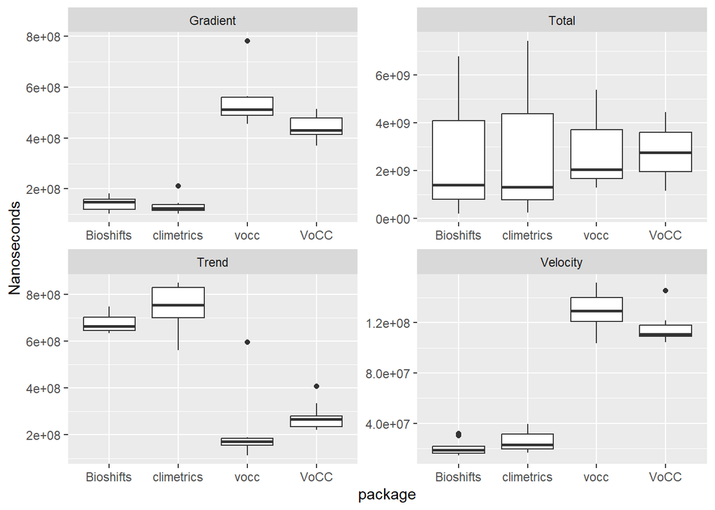

```r
ggplot(timesFuncs, aes(x = package, y = time)) +
  geom_boxplot() + ylab("Nanoseconds") +
  facet_wrap(.~fun, scales = "free")
```

The two packages that we use the package `terra` (`climetrics` and `bioshifts`) are the fastest for calculating the environmental gradient and velocity. However, the calculus of trend is faster when using the package `raster` (with `vocc` and `VoCC`). Overall, `climetrics` and `bioshifts` are the winners. I expect that the bioshifts function will shine when working with very large raster files because this is when a fast calculation of the environmental gradient will make the difference.

## 3.5 North direction velocities

Here, we can add biov1’s results for North velocity

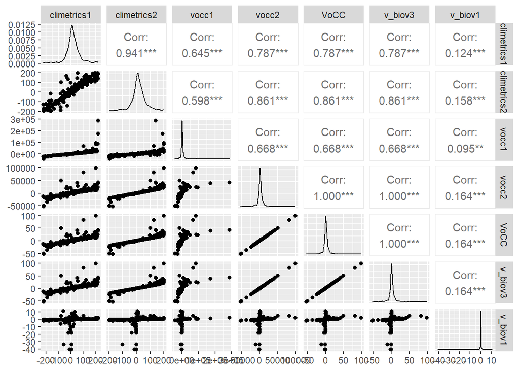

```r
# Convert all velocities to the North direction by multiplying velocities by the cosine of the inverse of the gradient angle (PS.: The inverse of the gradient angle == angle of the trajectory)
velocities_North <- data.frame(
  climetrics1=v_climetrics1[][,1] * cos(deg_to_rad((grad_ang_climetrics1 + 180) %% 360)),
  climetrics2=v_climetrics2[][,1] * cos(deg_to_rad((grad_ang_climetrics2 + 180) %% 360)),
  vocc1=v_vocc_rast1[][,1] * cos(deg_to_rad((grad_ang_vocc1 + 180) %% 360)),
  vocc2=v_vocc_rast2[][,1] * cos(deg_to_rad((grad_ang_vocc2 + 180) %% 360)),
  VoCC=v_VoCC$voccMag[]/1000 * cos(deg_to_rad((grad_ang_VoCC + 180) %% 360)),
  v_biov3=v_biov3[][,1] * cos(deg_to_rad((grad_ang_biov3 + 180) %% 360)),
  v_biov1=v_biov1[])

ggpairs(na.omit(velocities_North))
```

VoCC and bioshifts still identical.

Results from packages are different from results in methods from bioshifts v1. This is because in bioshifts v1 the velocity North is calculated by the division of trend by the gradient north. However, the gradient north can never be higher than the gradient unprojected (at the maximum it is equal to the unprojected gradient – NS + WE). Therefore, using the gradient north to divide the trend will result in velocities north higher then velocities unprojected, which should not be possible. The correct way to calculate velocity north is applying angle transformation using the approach above.

Here is proof that in bioshifts v1 the gradient north was used to divide the trend.

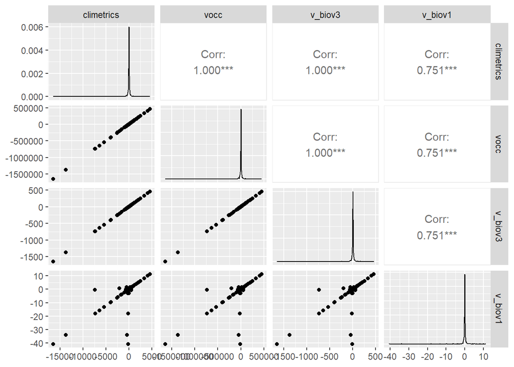

```r
# same as doing
velocities_North_wrong <- data.frame(
  climetrics=trend_climetrics[][,1] / spgrad_climetrics2$NS,
  vocc=trend_vocc$slope / spgrad_out_vocc2$NS,
  v_biov3=trend_biov3[][,1] / spgrad_biov3$NS,
  v_biov1=v_biov1[])

ind <- cells(v_climetrics1 > 0)

velocities_North_wrong$climetrics[ind] <- velocities_North_wrong$climetrics[ind] * -1
velocities_North_wrong$vocc[ind] <- velocities_North_wrong$vocc[ind] * -1
velocities_North_wrong$v_biov3[ind] <- velocities_North_wrong$v_biov3[ind] * -1

ggpairs(na.omit(velocities_North_wrong))
```

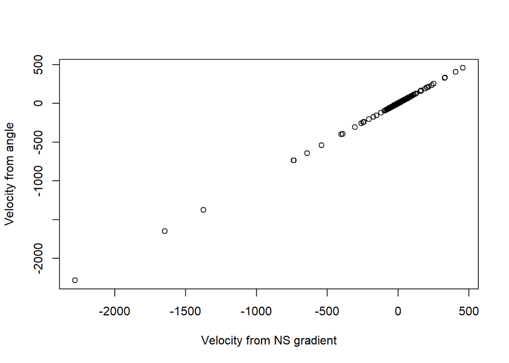

```r
plot((trend_biov3[][,1] / spgrad_biov3$NS) * -1,
     v_biov3[] / cos(deg_to_rad(v_biov3_angle[])),
     xlab = "Velocity from NS gradient",
     ylab = "Velocity from angle")
```

Velocities from `biov1` and `biov3` are very similar, but the magnitudes are different. This is because v1 provides the gradient in C/pixel. After fixing the scale of biov1 gradient by adding raster resolution we get similar scales relative to biov3.

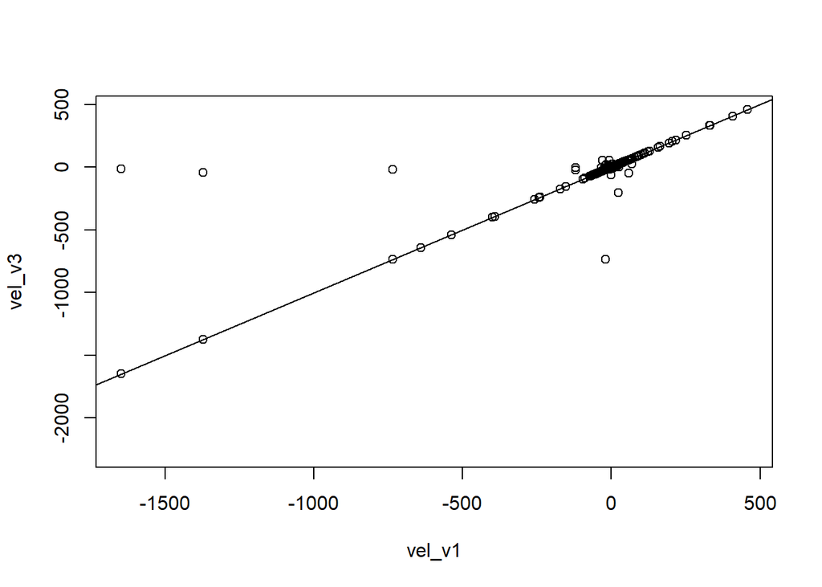

```r
test <- data.frame(vel_v3 = velocities_North_wrong$v_biov3,
                   vel_v1 = v_biov1[] * res(tmean)/1000)

test$a1=test$vel_v1*res(tmean)[1]
plot(vel_v3~vel_v1, test)
abline(a=0, b = 1)
```

# 4 Extra

## 4.1 Compare velocities with projected and unprojected raster files

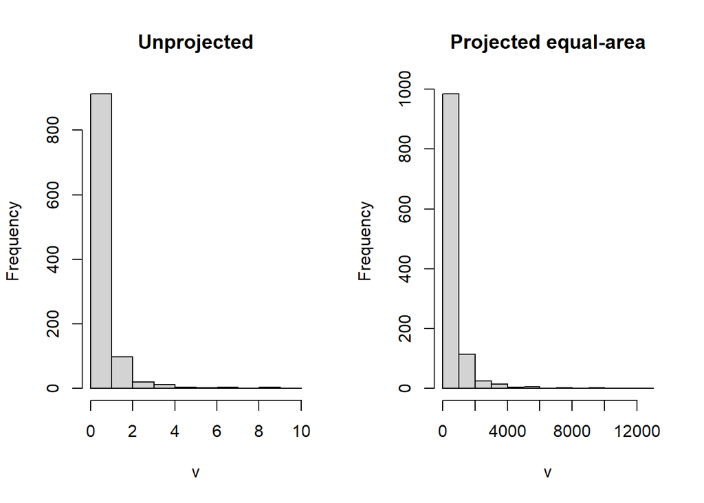

```r
# Use the same set of climate variables
tmean <- rast(paste0(filePath,'/tmean.tif'))
# project to equal-area
tmean_proj <- terra::project(tmean,Eckt)

# Use rts function in the rts package to make a raster time series:
tmean.t <- rts(tmean,n)
tmean.t_proj <- rts(tmean_proj,n)


####
# VoCC unprojected
# Trend
trend_VoCC = VoCC1::tempTrend(r = stack(tmean),
                              th = 0.25*nlyr(tmean))

# Spatial gradient
spgrad_VoCC = VoCC1::spatGrad(r = stack(tmean),
                              projected = FALSE)

# Velocity
v_VoCC = VoCC1::gVoCC(tempTrend = trend_VoCC,
                      spatGrad = spgrad_VoCC)

####
# VoCC projected
# Trend
trend_VoCC = VoCC1::tempTrend(r = stack(tmean_proj),
                              th = 0.25*nlyr(tmean_proj) ## set minimum # obs. to 1/4 time series length
)
# Spatial gradient
spgrad_VoCC = VoCC1::spatGrad(r = stack(tmean_proj),
                              projected = TRUE)
# Velocity
v_VoCC2 = VoCC1::gVoCC(tempTrend = trend_VoCC,
                       spatGrad = spgrad_VoCC)

## Compare velocities
{
  par(mfrow=c(1,2))
  hist(v_VoCC[[1]],main="Unprojected")
  hist(v_VoCC2[[1]],main="Projected equal-area")
  par(mfrow=c(1,1))
}
```

```r
####
# bioshifts unprojected
# Trend
trend_biov3_ <- temp_grad(tmean, th = 0.25*nlyr(tmean))
# Spatial gradient
spgrad_biov3_ <- spatial_grad(tmean)
```

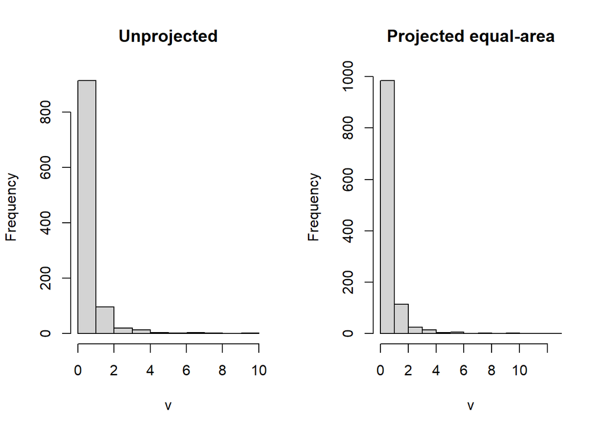

```r
# Velocity
v_biov3_ <- gVelocity(spgrad_biov3_,trend_biov3_)

####
# bioshifts projected
# Trend
trend_biov3_ <- temp_grad(tmean_proj, th = 0.25*nlyr(tmean_proj))
# Spatial gradient
spgrad_biov3_ <- spatial_grad(tmean_proj)
# Velocity
v_biov32 <- gVelocity(spgrad_biov3_,trend_biov3_)

## Compare velocities
{
  par(mfrow=c(1,2))
  hist(v_biov3_[[1]],main="Unprojected")
  hist(v_biov32[[1]],main="Projected equal-area")
  par(mfrow=c(1,1))
}
```

## 4.2 Why VoCC results are different when using projected and unprojected data?

Inspection of VoCC package functions indicates that when using projected data, the results are given in the unit of the environmental data provided. As the unit of projected data is usually in meters, the results of the unprojected data are 1000 smaller then the projected (1km = 1000 meters). To make results identical between projected and unprojected data (both in C/km), transform units:

```r
summary(v_VoCC[[1]])
```

```
##              voccMag
## Min.      0.02282359
## 1st Qu.   0.16517678
## Median    0.34051253
## 3rd Qu.   0.63029609
## Max.      9.90459499
## NA's    726.00000000
```

```r
summary(v_VoCC2[[1]]/1000)
```

```
##              voccMag
## Min.      0.02477245
## 1st Qu.   0.18575202
## Median    0.39378280
## 3rd Qu.   0.69185021
## Max.             Inf
## NA's    846.00000000
```

## 4.3 Get gradient North from undirectional gradient

Tests whether we can use velocity North provided directly from the function output, or if it’s necessary to calculate the resultant velocity North from the angle of the gradient.

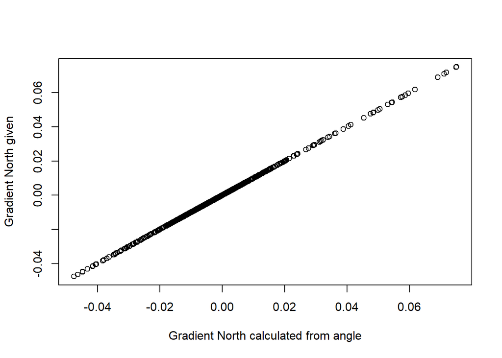

```r
# get data
v_data <- na.omit(spgrad_biov3)

# Convert gradients to the North direction using the angle
vel_gradient <- v_data$Grad  # °C/km
vel_angle <- v_data$angle

# Calculate temperature change in North and East directions
gradient_north_calculated <- vel_gradient * cos(deg_to_rad(vel_angle))
gradient_east_calculated <- vel_gradient * sin(deg_to_rad(vel_angle))

plot(gradient_north_calculated,v_data$NS,
     xlab="Gradient North calculated from angle",ylab = "Gradient North given")
```

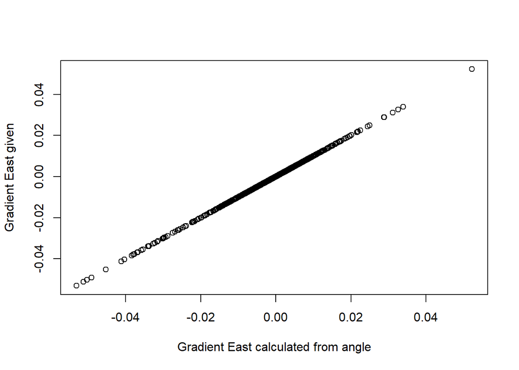

```r
plot(gradient_east_calculated,v_data$WE,
     xlab="Gradient East calculated from angle",ylab = "Gradient East given")
```

```r
all.equal(v_data$NS,gradient_north_calculated)
```

```
## [1] TRUE
```

```r
all.equal(v_data$WE,gradient_east_calculated)
```

```
## [1] TRUE
```

According to the calculations below, we can use the gradient North directly. It is not necessary to convert velocity rates to the North direction using angles.

## 4.4 Understanding angles

We expect velocity North to be greater when angle is North, and same direct comparison for South direction.

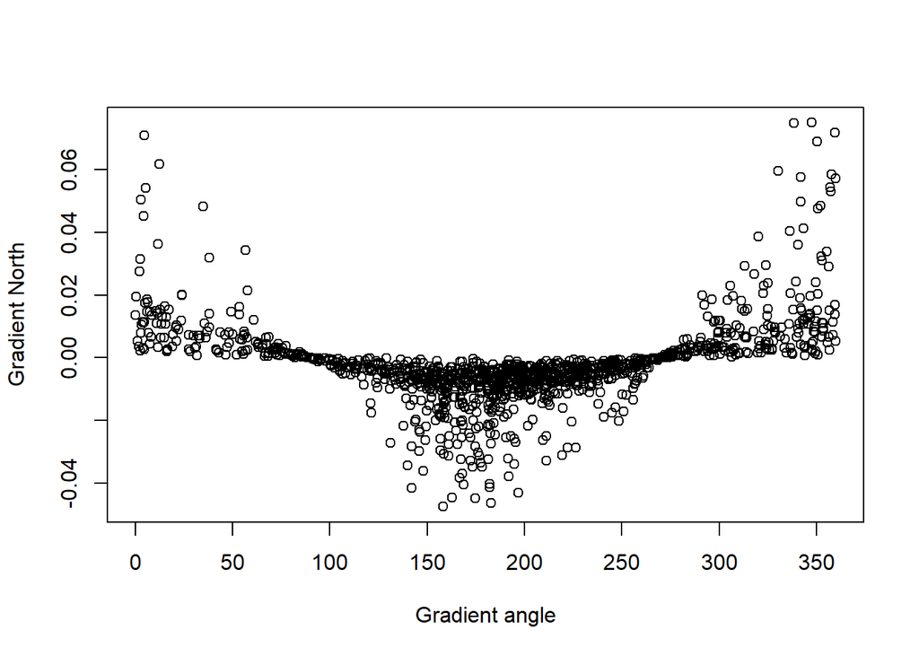

```r
plot(v_data$angle,v_data$NS,
     xlab="Gradient angle",ylab = "Gradient North")
```

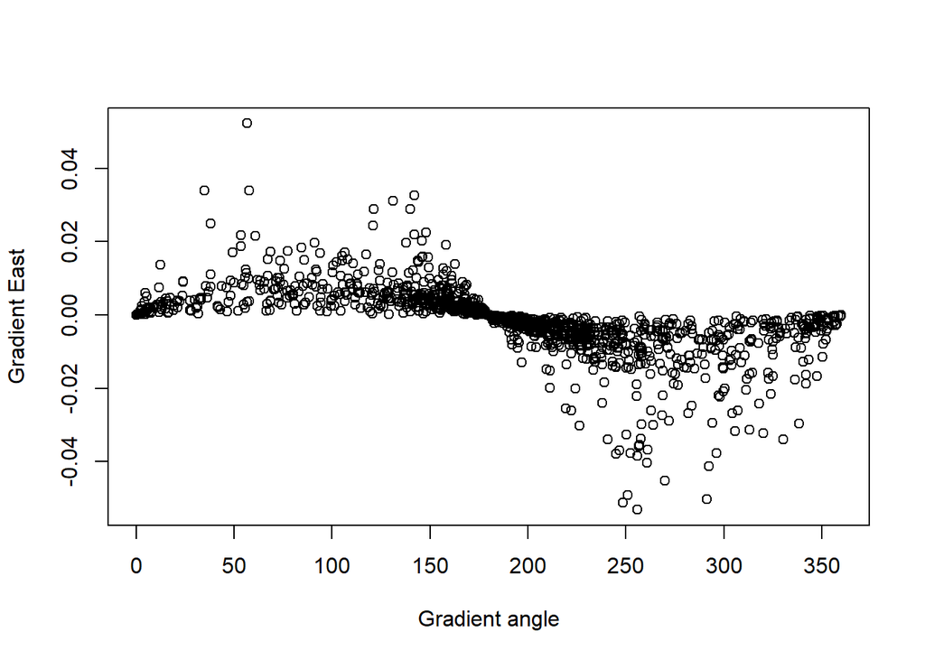

```r
plot(v_data$angle,v_data$WE,
     xlab="Gradient angle",ylab = "Gradient East")
```

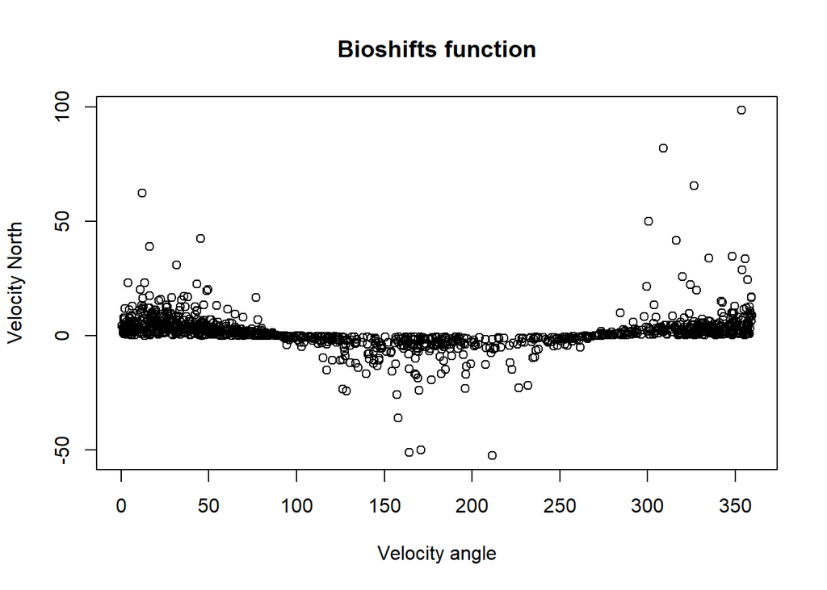

```r
###################
plot(v_biov3_angle$Ang[], v_biov3$Vel[] * cos(deg_to_rad(v_biov3_angle$Ang))[],
     main = "Bioshifts function",
     xlab="Velocity angle",ylab = "Velocity North")
```

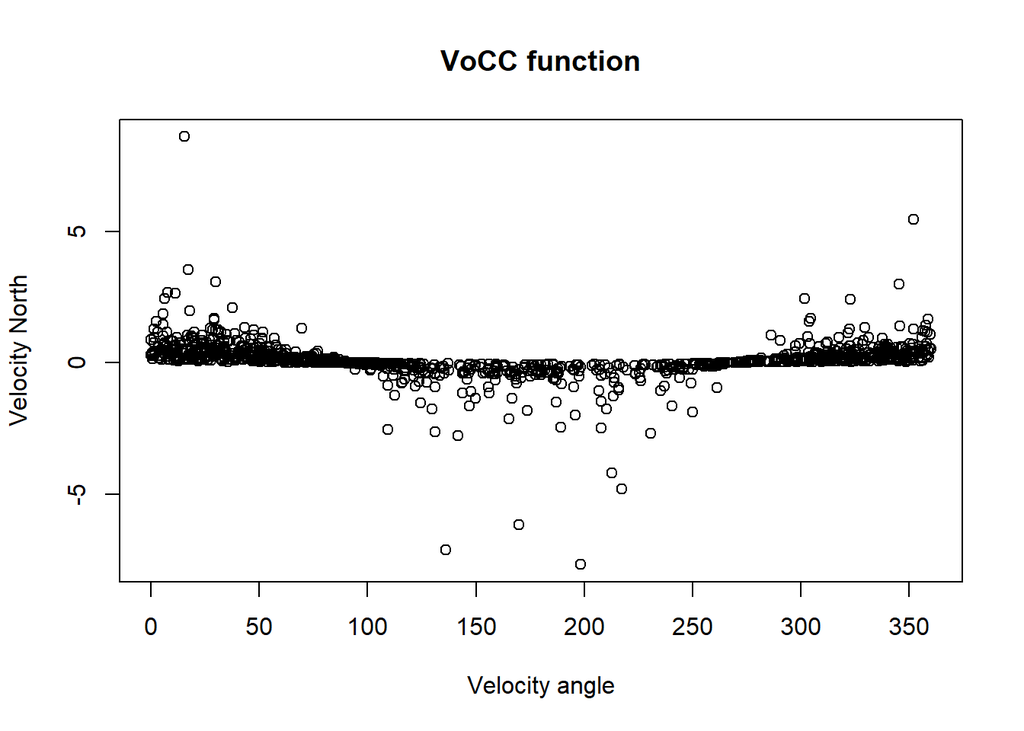

```r
plot(v_VoCC$voccAng[], v_VoCC$voccMag[] * cos(deg_to_rad(v_VoCC$voccAng))[],
     main = "VoCC function",
     xlab="Velocity angle",ylab = "Velocity North")
```

## 4.5 Visualize angles and bearings

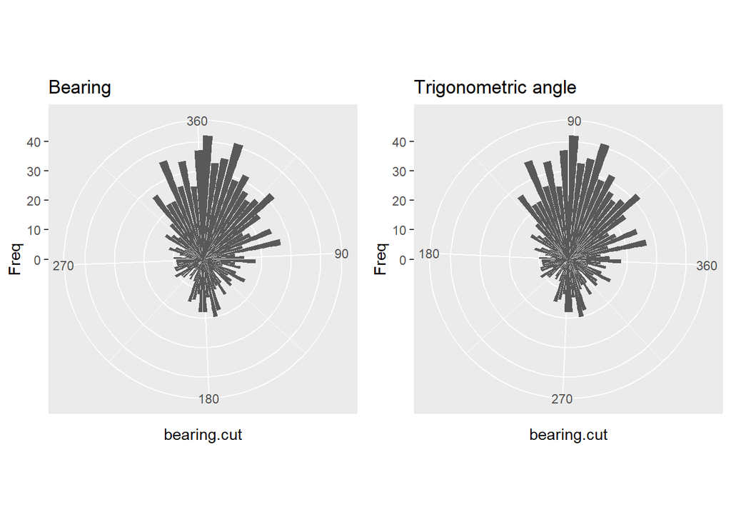

```r
# 0º at North and clockwise
bearing <- v_biov3_angle[][,1]

#create histogram
breaks = seq(0, 360, by=5)    # half-integer sequence
bearing.cut = cut(bearing, breaks, right=FALSE)
bearing.freq = as.data.frame(table(bearing.cut))
bearing.freq$bearing.cut <- seq(5,360, by = 5)

#plot
p1 <- ggplot(bearing.freq, aes(x = bearing.cut, y = Freq)) +
  coord_polar(theta = "x", start =0, direction = 1) +
  geom_bar(stat = "identity") +
  scale_x_continuous(breaks = seq(0, 360, 90))+
  ggtitle("Bearing")

# transform to 0º at E and counterclockwise
bearing2 <- bearing_to_angle(bearing)

#create histogram
bearing.cut2 = cut(bearing2, breaks, right=FALSE)
bearing.freq2 = as.data.frame(table(bearing.cut2))
bearing.freq2$bearing.cut <- seq(5,360, by = 5)

# plot
p2 <- ggplot(bearing.freq2, aes(x = bearing.cut, y = Freq)) +
  coord_polar(theta = "x", start = -pi/2, direction = -1) +
  geom_bar(stat = "identity") +
  scale_x_continuous(breaks = seq(0, 360, 90))+
  ggtitle("Trigonometric angle")

grid.arrange(p1, p2, ncol=2)
```

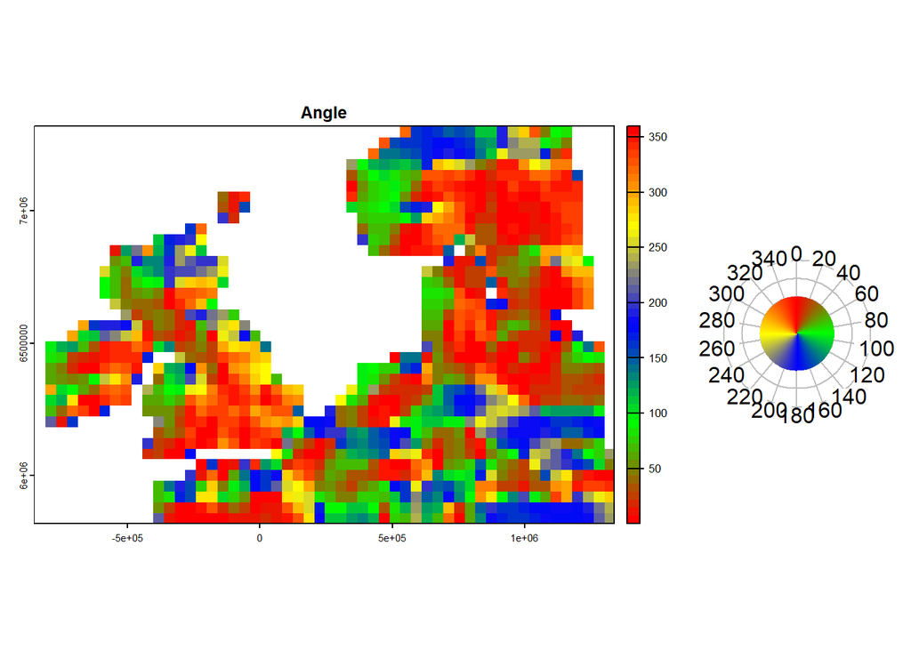

```r
###########################################
# Map angle
angle_map(v_biov3_angle, main = "Angle")
```

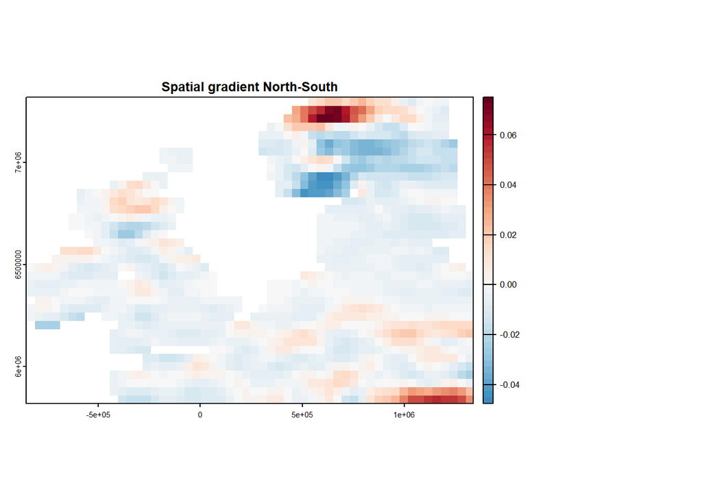

```r
# Map gradient NS
grad_rast <- v_biov3
grad_rast[spgrad_biov3$icell] <- spgrad_biov3$NS

velocity_map(grad_rast, main = "Spatial gradient North-South")
```